# Reason Analysis for the Rise of Toranto Fire Incidents

Zijian Wang

2020/9/27

# 1.Introduction

```r
package <- show_package("64a26694-01dc-4ec3-aa87-ad8509604f50")
resources <- list_package_resources("64a26694-01dc-4ec3-aa87-ad8509604f50")
datastore_resources <- filter(resources, tolower(format) %in% c('csv'))
dtRaw <- data.table(filter(datastore_resources, row_number()==1) %>% get_resource())
```

# 2.Data

```r
dtRaw <- fread("Fire Incidents Data.csv")
dtRaw[,":="(date=as.Date(str_sub(dtRaw$TFS_Alarm_Time,0,10)),
            hour=as.numeric(str_sub(dtRaw$TFS_Alarm_Time,12,13)))]
dtRaw$ym <- as.numeric(paste0(str_sub(dtRaw$date,0,4),
                              str_sub(dtRaw$date,6,7)))
dtRaw$ymAxis <- paste0(str_sub(dtRaw$ym,0,4),"-",
                       str_sub(dtRaw$ym,5,6))
dtRaw$ymFirstDay <- as.Date(paste0(dtRaw$ymAxis,"-01"))
dtRaw$period <- "Before"
dtRaw$period[dtRaw$date>=as.Date("2018-02-01")] <- "After"
head(dtRaw[,c("TFS_Alarm_Time","Incident_Station_Area","Possible_Cause")])
```

```
##         TFS_Alarm_Time Incident_Station_Area           Possible_Cause
## 1: 2018-02-24T21:04:29                   441        99 - Undetermined
## 2: 2018-02-24T21:24:43                   116 03 - Suspected Vandalism
## 3: 2018-02-25T13:29:59                   221
## 4: 2018-02-25T14:13:39                   133        99 - Undetermined
## 5: 2018-02-25T18:20:43                   132
## 6: 2018-02-25T18:31:19                   215        99 - Undetermined
```

```r
tail(dtRaw[,c("TFS_Alarm_Time","Incident_Station_Area","Possible_Cause")])
```

```
##         TFS_Alarm_Time Incident_Station_Area
## 1: 2018-02-24T01:30:45                   222
## 2: 2018-02-24T02:30:33                   222
## 3: 2018-02-24T17:55:59                   121
## 4: 2018-02-24T00:15:10                   212
## 5: 2018-02-24T00:34:12                   141
## 6: 2018-02-24T08:22:30                   413
##                                    Possible_Cause
## 1:                        52 - Electrical Failure
## 2: 60 - Other unintentional cause, not classified
## 3:
## 4:                              99 - Undetermined
## 5:                      45 - Improperly Discarded
## 6:                      45 - Improperly Discarded
```

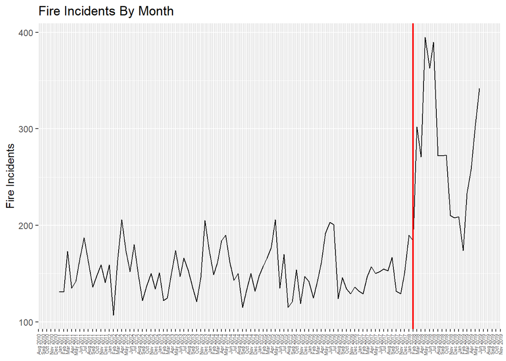

```r
dtMonth <- dtRaw[,.N,by=ymFirstDay]
ggplot(dtMonth,aes(x=ymFirstDay,y=N))+
  geom_line()+
  labs(x="",y="Fire Incidents")+
  ggtitle("Fire Incidents By Month")+
  scale_x_date(NULL, date_labels = "%b %Y", breaks = "month")+
  theme(axis.text.x = element_text(angle = 90, vjust = 0.5, hjust=1,size=5))+
  geom_vline(xintercept = as.Date("2018-02-01"),
             color="red",size=0.811)
```

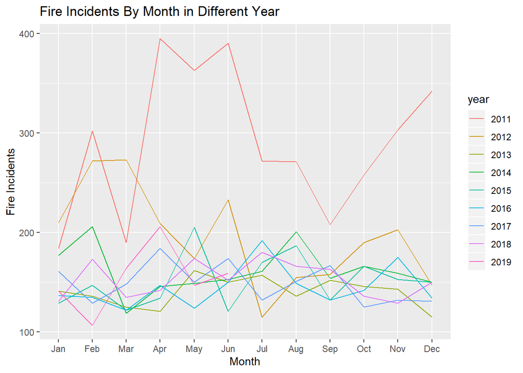

```r
fiMonth <- ts(dtMonth$N,start = 2011,frequency = 12)
ggseasonplot(fiMonth)+
  labs(x="Month",y="Fire Incidents")+
  ggtitle("Fire Incidents By Month in Different Year")
```

As we refine to the day, the figure presents similar pattern.

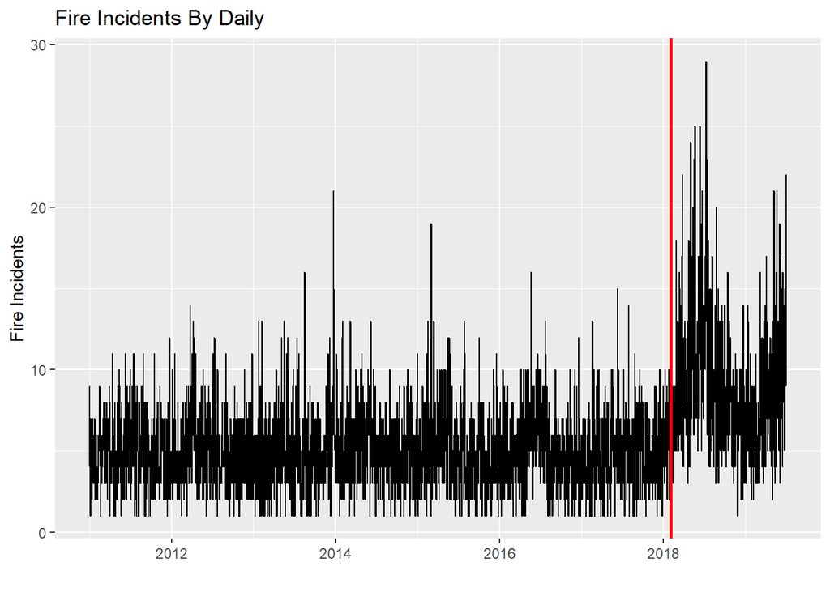

```r
dtDay <- dtRaw[,.N,by=date]
ggplot(dtDay,aes(x=date,y=N))+
  geom_line()+
  labs(x="",y="Fire Incidents")+
  ggtitle("Fire Incidents By Daily")+
  geom_vline(xintercept = as.Date("2018-02-01"),
             color="red",size=1.011)
```

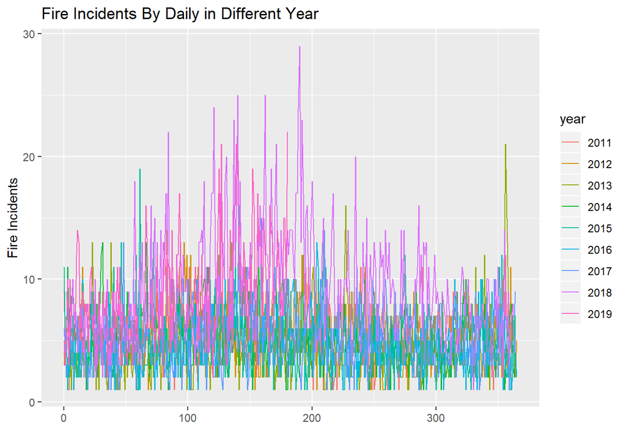

```r
dtDay$year <- year(dtDay$date)
dtDay$yearFirstDay <- as.Date(paste0(dtDay$year,"-01-01"))
dtDay$dayLen <- as.numeric(dtDay$date-dtDay$yearFirstDay)
dtDay$year <- as.character(dtDay$year)
ggplot(dtDay,aes(x=dayLen,y=N,color=year))+
  geom_line()+
  labs(x="",y="Fire Incidents")+
  ggtitle("Fire Incidents By Daily in Different Year")
```

# 3.Discussion

This part of essay committed to find where and why fire incidents rise. If we find which area take place more fire incidents we can put more fire forces in these area. If we find which cause brought more fire incidents we need to pay more attention to these causes.

## 3.1 Test of difference

Before plunge into find where and why fire incidents rise, we must use statistical test method to confirm whether there are more fire incidents each month/day after February 2018 than before February 2018.

### 3.1.1 Month

Compare monthly fire incidents before and after February 2018.

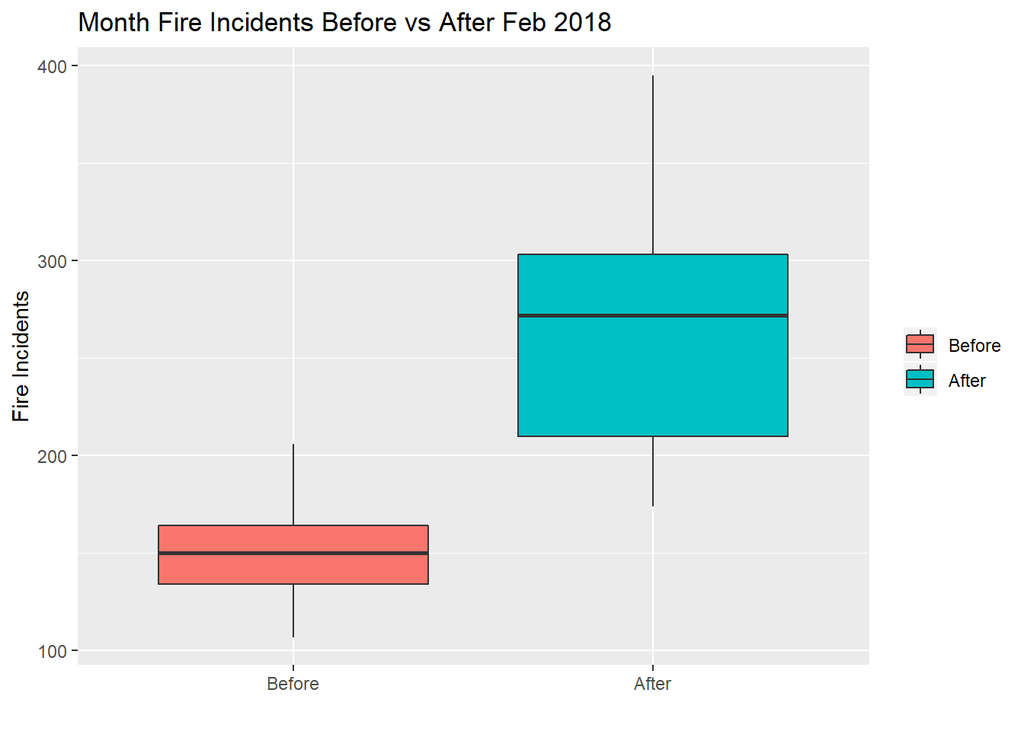

```r
dtMonth$period <- "Before"
dtMonth$period[dtMonth$ymFirstDay>=as.Date("2018-02-01")] <- "After"
dtMonth$period <- factor(dtMonth$period,
                       level=c("Before","After"))
dtMonth <- dtMonth[order(dtMonth$ymFirstDay),]
ggplot(dtMonth,aes(x=period,y=N,fill=period))+
  geom_boxplot()+
  labs(x="",y="Fire Incidents")+
  ggtitle("Month Fire Incidents Before vs After Feb 2018")+
  theme(legend.title = element_blank())
```

To avoid assumption of normally distribution, we choose Wilcoxon Rank Sum Test which is non-parametric test to test whether there are more fire incidents each month/day after February 2018 than before February 2018.  
The null hypothesis (H0): the median of fire incidents amount after February 2018 is less or same as before February 2018.  
The alternative hypothesis (Ha): the median of fire incidents amount after February 2018 is larger than before February 2018.  
The p-value of the test is less than the significance level alpha = 0.05. We can conclude that there are more fire incidents after February 2018 than before February 2018.

```r
wilcox.test(dtMonth$N[dtMonth$period=="After"],
            dtMonth$N[dtMonth$period=="Before"],alternative = "greater")
```

```
##
##  Wilcoxon rank sum test with continuity correction
##
## data:  dtMonth$N[dtMonth$period == "After"] and dtMonth$N[dtMonth$period == "Before"]
## W = 1421.5, p-value = 0.0000000001764
## alternative hypothesis: true location shift is greater than 0
```

### 3.1.2 Daily

As we refine to the day, the test presents similar conclusion.

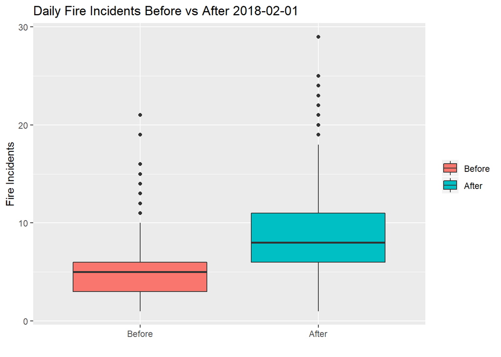

```r
dtDay$period <- "Before"
dtDay$period[dtDay$date>as.Date("2018-02-01")] <- "After"
dtDay$period <- factor(dtDay$period,
                          level=c("Before","After"))
dtDay <- dtDay[order(dtDay$date),]
ggplot(dtDay,aes(x=period,y=N,fill=period))+
  geom_boxplot()+
  labs(x="",y="Fire Incidents")+
  ggtitle("Daily Fire Incidents Before vs After 2018-02-01")+
  theme(legend.title = element_blank())
```

As we refine to the day, the test presents similar conclusion.

```r
wilcox.test(dtDay$N[dtDay$period=="After"],
            dtDay$N[dtDay$period=="Before"],alternative = "greater")
```

```
##
##  Wilcoxon rank sum test with continuity correction
##
## data:  dtDay$N[dtDay$period == "After"] and dtDay$N[dtDay$period == "Before"]
## W = 1043073, p-value < 0.00000000000000022
## alternative hypothesis: true location shift is greater than 0
```

### 3.1.3 Trend

```r
fiMonthBefore <- ts(dtMonth$N[dtMonth$period=="Before"],
                    start=2011,
                    frequency=12)
summary(SeasonalMannKendall(fiMonthBefore))
```

```
## Score =  -14 , Var(Score) = 546
## denominator =  255.4445
## tau = -0.0548, 2-sided pvalue =0.54908
```

As we refine to daily, the test presents similar conclusion.

```r
fiDailyBefore <- ts(dtDay$N[dtDay$period=="Before"],
                    start=2011,
                    frequency=365)
summary(SeasonalMannKendall(fiDailyBefore))
```

```
## Score =  39 , Var(Score) = 15170.33
## denominator =  7199.681
## tau = 0.00542, 2-sided pvalue =0.75152
```

## 3.2 Area

There are 84 TFS Station area in Toronto.

```r
length(unique(dtRaw$Incident_Station_Area))
```

```
## [1] 84
```

Different station area have different status. We calculte average fire incidents of each station area everyday before and after February 2018 and minus them. The table below show result.

```r
dtBASA <- dtRaw[,.N,by=c("period","Incident_Station_Area")]
daysBefore <- length(unique(dtRaw$date[dtRaw$period=="Before"]))
daysAfter <- length(unique(dtRaw$date[dtRaw$period=="After"]))
dtBASA$mean[dtBASA$period=="Before"] <-
  dtBASA$N[dtBASA$period=="Before"]/daysBefore
dtBASA$mean[dtBASA$period=="After"] <-
  dtBASA$N[dtBASA$period=="After"]/daysAfter

dtBASA2 <- dcast(dtBASA[,c("period","Incident_Station_Area","mean")],
                 Incident_Station_Area~period,
                 value.var = "mean")
dtBASA2[is.na(dtBASA2)] <- 0
dtBASA2$Diff <- dtBASA2$After-dtBASA2$Before
dtBASA2 <- dtBASA2[order(dtBASA2$Diff),]
dtBASA3 <- dtBASA2[order(-dtBASA2$Diff),]
names(dtBASA3) <- c("Station Area",
                    "Average Daily Fires Before Feb 2018",
                    "Average Daily Fires After Feb 2018",
                    "Difference (After-Before)")
head(dtBASA3)
```

[output not shown]

The rise in station area 314 is largest which reach 0.2 fire incidents everyday. And there are also two station area which have less fire incidents after February 2018 than before. But fire incidents most of station area rise as the figure below.

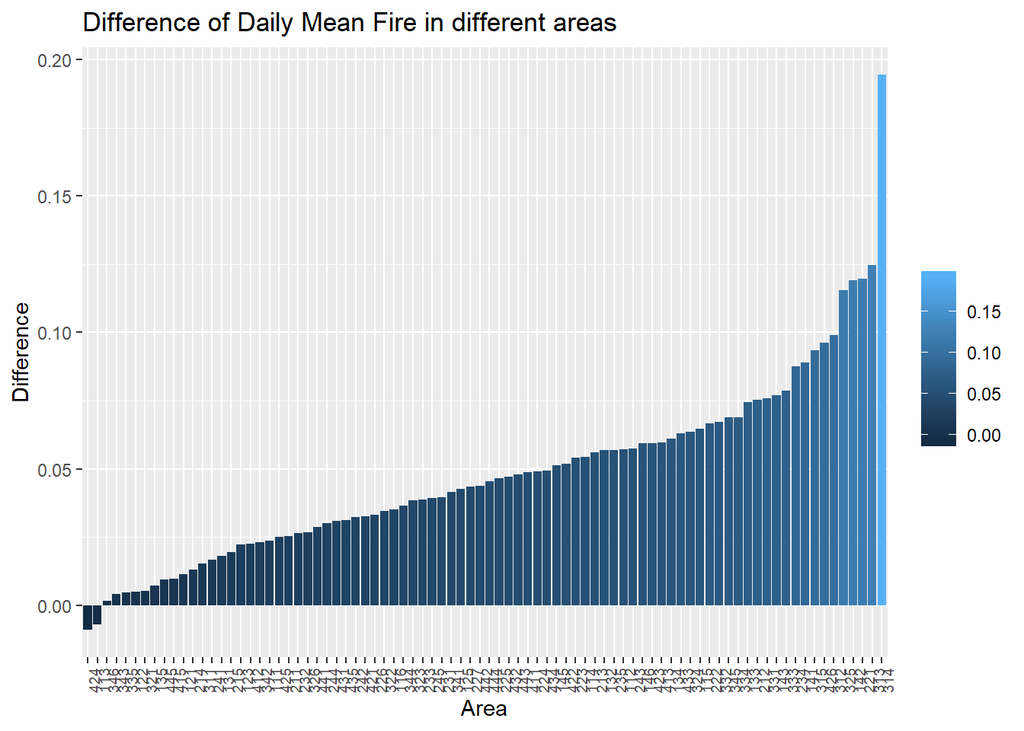

```r
dtBASA2$Incident_Station_Area <- factor(dtBASA2$Incident_Station_Area,
                                        level=dtBASA2$Incident_Station_Area[order(dtBASA2$Diff)])
ggplot(dtBASA2,aes(x=Incident_Station_Area,y=Diff,fill=Diff))+
  geom_bar(position="dodge", stat="identity")+
  theme(axis.text.x = element_text(angle = 90,size=7),
        legend.title = element_blank())+
  labs(x="Area",y="Difference")+
  ggtitle("Difference of Daily Mean Fire in different areas")
```

To make sure the difference of mean really describe the pattern of change. We define function to implement Wilcoxon Rank Sum Test to each station area.

```r
compareAreaByWilcox <- function(area){
  dtS = dtRaw[dtRaw$Incident_Station_Area==area,]
  dtSN = dtS[,.N,by=date]
  allDate = data.table(date=unique(dtRaw$date))
  dtSN = merge(dtSN,allDate,all=T)
  dtSN$N[is.na(dtSN$N)]=0
  dtSN$period = "Before"
  dtSN$period[dtSN$date>as.Date("2019-02-01")] = "After"
  rs = data.table(area=area,
                  greater=wilcox.test(dtSN$N[dtSN$period=="After"],
                                      dtSN$N[dtSN$period=="Before"],
                                      alternative = "greater")$p.value,
                  less=wilcox.test(dtSN$N[dtSN$period=="After"],
                                   dtSN$N[dtSN$period=="Before"],
                                   alternative = "less")$p.value)
  return(rs)
}
rsArea <- data.table()
for (areaCode in unique(dtRaw$Incident_Station_Area)) {
  rs = compareAreaByWilcox(area=areaCode)
  rsArea = rbind(rsArea,rs)
}
greaterArea <- rsArea$area[rsArea$greater<0.05]
dtBASA2$change <- "Fixed"
```

The figure above show both difference and conclusion of test of each station area. The red bar symbol station area without significant rise and green bar symbol station area with more fire incidents after February 2018.

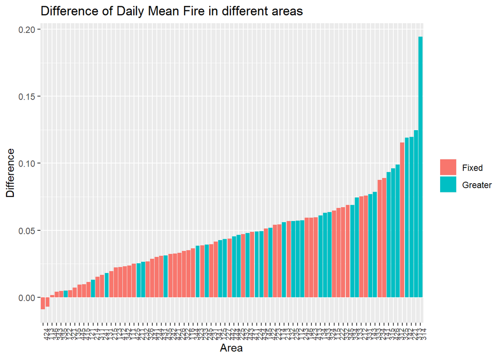

```r
dtBASA2$change[dtBASA2$Incident_Station_Area %in% greaterArea] <- "Greater"
ggplot(dtBASA2,aes(x=Incident_Station_Area,y=Diff,fill=change))+
  geom_bar(position="dodge", stat="identity")+
  theme(axis.text.x = element_text(angle = 90,size=7),
        legend.title = element_blank())+
  labs(x="Area",y="Difference")+
  ggtitle("Difference of Daily Mean Fire in different areas")
```

```r
plotArea <- function(area){
  dtS = dtRaw[dtRaw$Incident_Station_Area==area,]
  dtSN = dtS[,.N,by=date]
  pic = ggplot(dtSN,aes(x=date,y=N))+
    geom_bar(position="dodge", stat="identity",width=12.23)+
    labs(y="Fire Incidents",x="")+
    ggtitle(paste0("Fire Incidents in Station Area ",area))
  return(pic)
}
```

For example, station area 141. We can see that there are 7 fire incidents at one day in 2019. We don’t know what happen in that tragic day but outlier affect difference and the pattern is not change.

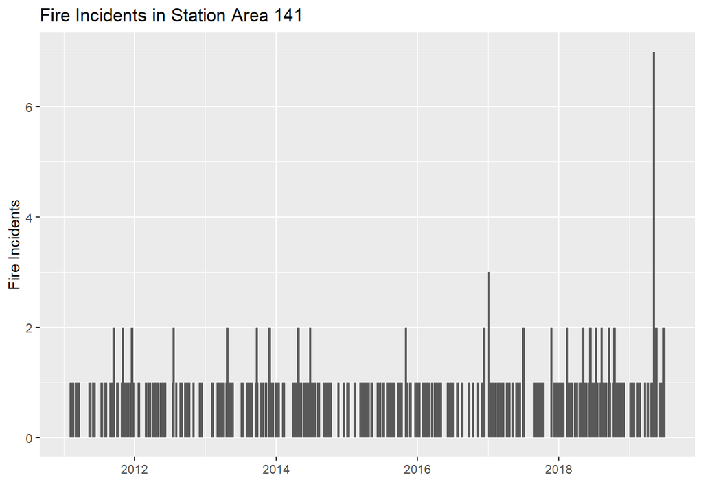

```r
plotArea(141)
```

Situation of station area 314 is more common. The figure show below reveal more fire incidents after February 2018.

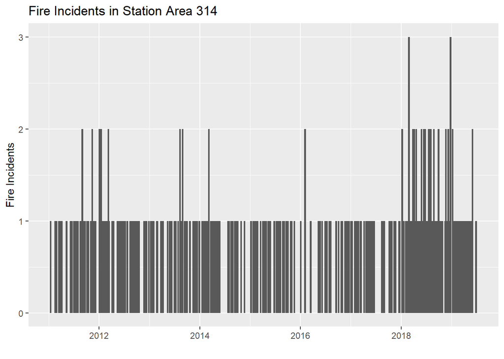

```r
plotArea(314)
```

Situation of station area 421 is also common. Difference is negligible and pattern is truly not change.

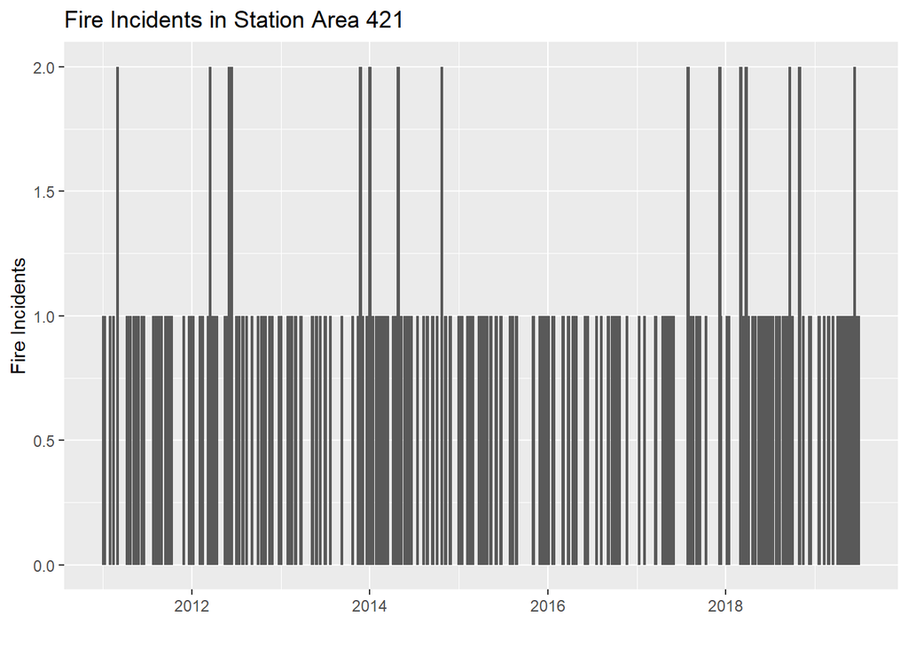

```r
plotArea(421)
```

We extract all station area which have more fire incidents after February 2018 as table below.

```r
dtBASA2[dtBASA2$change=="Greater",]
```

```
##     Incident_Station_Area      After     Before        Diff  change
##  1:                   122 0.03696498 0.03209393 0.004871047 Greater
##  2:                   214 0.05447471 0.04148728 0.012987428 Greater
##  3:                   131 0.04474708 0.02661448 0.018132600 Greater
##  4:                   211 0.07198444 0.04657534 0.025409093 Greater
##  5:                   232 0.08949416 0.06301370 0.026480465 Greater
##  6:                   435 0.08171206 0.05048924 0.031222825 Greater
##  7:                   323 0.09727626 0.05870841 0.038567850 Greater
##  8:                   245 0.09143969 0.05205479 0.039384894 Greater
##  9:                   125 0.07198444 0.02935421 0.042630228 Greater
## 10:                   227 0.07392996 0.03052838 0.043401585 Greater
## 11:                   444 0.07587549 0.03052838 0.045347111 Greater
## 12:                   225 0.12256809 0.07592955 0.046638543 Greater
## 13:                   443 0.10311284 0.05518591 0.047926930 Greater
## 14:                   224 0.10505837 0.05596869 0.049089677 Greater
```

[output cut: 21 more lines]

## 3.3 Cause

There are 25 cause in th dataset.

```r
length(unique(dtRaw$Possible_Cause))
```

```
## [1] 25
```

```r
unique(dtRaw$Possible_Cause)
```

```
##  [1] "99 - Undetermined"
##  [2] "03 - Suspected Vandalism"
##  [3] ""
##  [4] "20 - Design/Construction/Installation/Maintenance Deficiency"
##  [5] "52 - Electrical Failure"
##  [6] "46 - Used or Placed too close to combustibles"
##  [7] "44 - Unattended"
##  [8] "28 - Routine maintenance deficiency, eg creosote, lint, grease buildup"
##  [9] "98 - Unintentional, cause undetermined"
## [10] "80 - Exposure fire"
## [11] "60 - Other unintentional cause, not classified"
## [12] "51 - Mechanical Failure"
## [13] "47 - Improper handling of ignition source or ignited material"
## [14] "45 - Improperly Discarded"
## [15] "01 - Suspected Arson"
## [16] "50 - Other misuse of ignition source/material ignited"
## [17] "49 - Improper Storage"
## [18] "48 - Used for purpose not intended"
## [19] "11 - Children Playing (Ages 11 and under)"
## [20] "12 - Vehicle Accident/Collision"
## [21] "04 - Suspected Youth Vandalism (Ages 12 to 17)"
## [22] "990 - Under Investigation"
## [23] "73 - Natural Cause"
## [24] "02 - Riot/Civil Commotion"
## [25] "72 - Rekindle"
```

For convenience, we truncated string and generate a new column Possible_Cause_abb as abbreviation of Possible_Cause. And both missing value,“990 - Under Investig” and “99 - Undetermined” are unkown so we put them into one category.

```r
dtRaw$Possible_Cause_abb <- str_sub(dtRaw$Possible_Cause,0,20)
dtRaw$Possible_Cause_abb[dtRaw$Possible_Cause_abb %in%
                           c("990 - Under Investig",
                             "99 - Undetermined",
                             "")] <- "99 - Unknown"
```

Then observe change by visualzation.

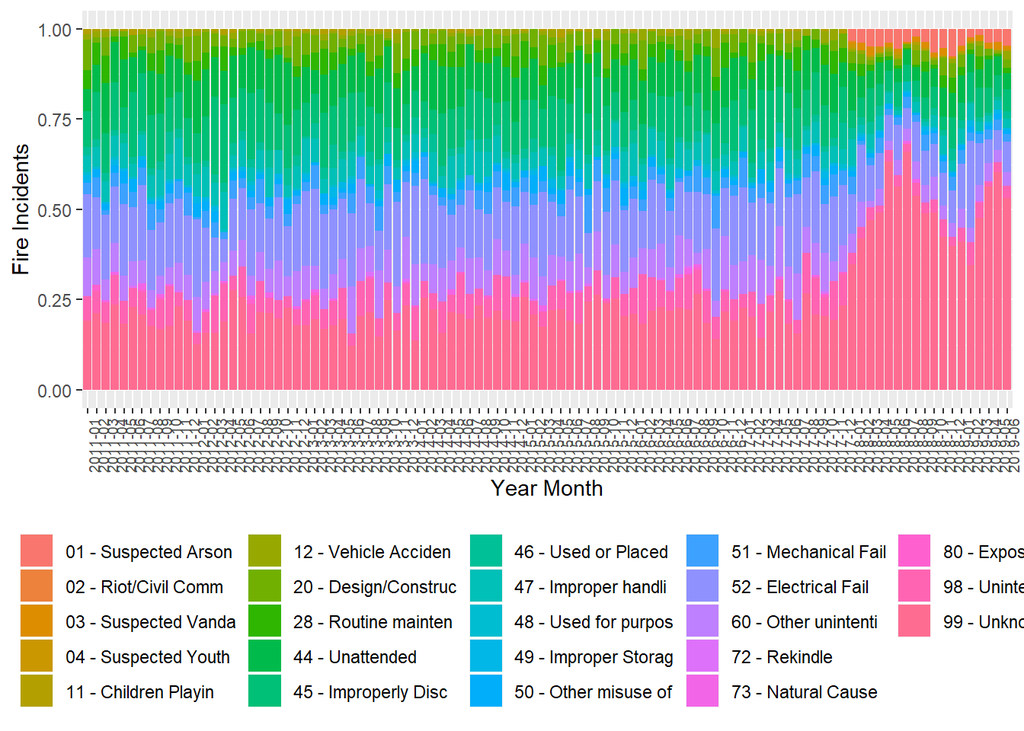

```r
dtC <- dtRaw[,.N,by=c("ymAxis","Possible_Cause_abb")]
ggplot(dtC, aes(fill=Possible_Cause_abb, y=N, x=ymAxis)) +
  geom_bar(position="fill", stat="identity")+
  theme(legend.position="bottom",
        legend.title = element_blank(),
        axis.text.x = element_text(angle = 90,size=7))+
  labs(x="Year Month",y="Fire Incidents")
```

Then ompare daily fire incidents for each cause before and after February 2018.

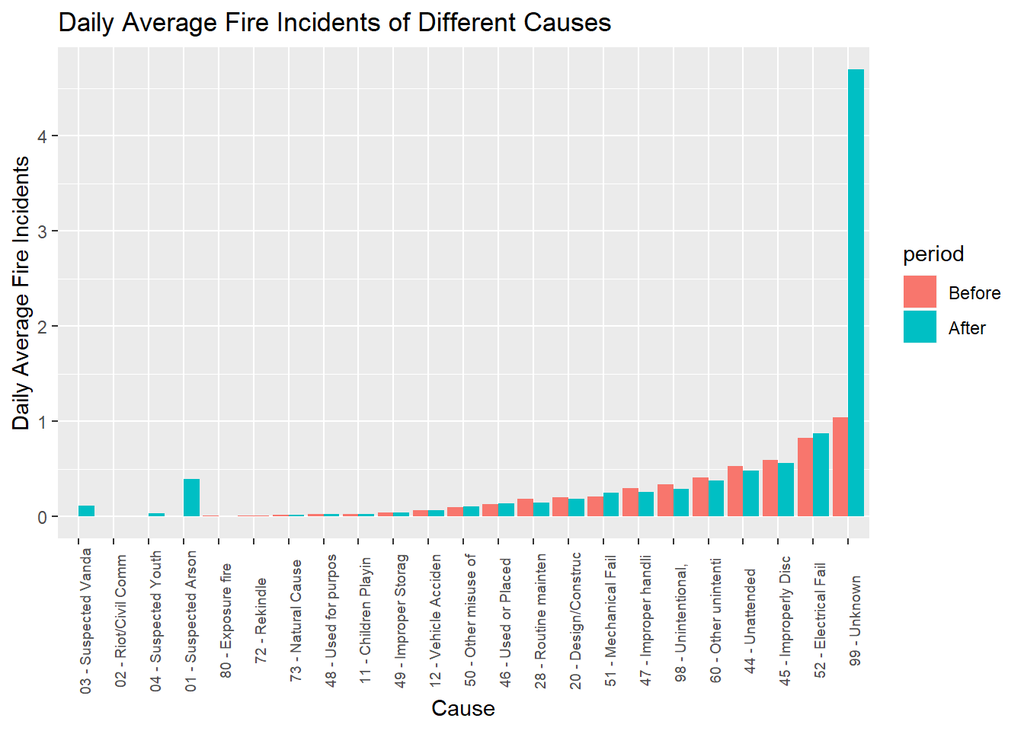

```r
dtRaw$period <- "Before"
dtRaw$period[dtRaw$date>=as.Date("2018-02-01")] <- "After"
dtCauseMean <- dtRaw[,.N,by=c("period","Possible_Cause_abb")]
daysBefore <- length(unique(dtRaw$date[dtRaw$period=="Before"]))
daysAfter <- length(unique(dtRaw$date[dtRaw$period=="After"]))
dtCauseMean$mean[dtCauseMean$period=="Before"] <-
  dtCauseMean$N[dtCauseMean$period=="Before"]/daysBefore
dtCauseMean$mean[dtCauseMean$period=="After"] <-
  dtCauseMean$N[dtCauseMean$period=="After"]/daysAfter
dtCauseMean$period <- factor(dtCauseMean$period,
                             level=c("Before","After"))
dtCauseMean$Possible_Cause_abb <- factor(dtCauseMean$Possible_Cause_abb,
                             level=unique(dtCauseMean$Possible_Cause_abb[order(dtCauseMean$mean)]))
ggplot(dtCauseMean,aes(x=Possible_Cause_abb,y=mean,fill=period))+
  geom_bar(position="dodge", stat="identity")+
  theme(axis.text.x = element_text(angle = 90,size=7))+
  labs(x="Cause",y="Daily Average Fire Incidents")+
  ggtitle("Daily Average Fire Incidents of Different Causes")
```

Then order cause by the difference of fire incidents before and after February 2018.

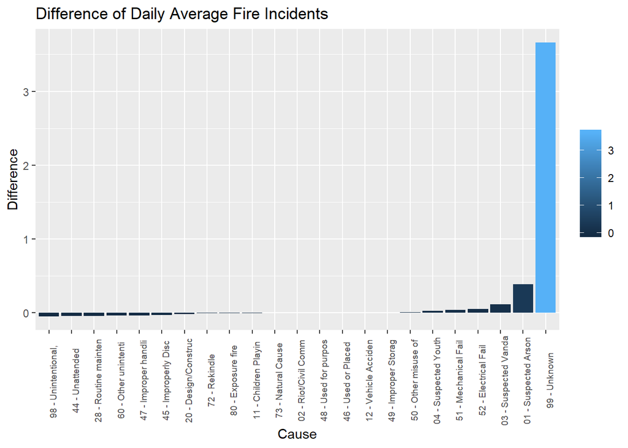

```r
dtCauseMean2 <- dcast(dtCauseMean[,c("period","Possible_Cause_abb","mean")],
                      Possible_Cause_abb~period,
                      value.var = "mean")
dtCauseMean2[is.na(dtCauseMean2)] <- 0
dtCauseMean2$diff <- dtCauseMean2$After-dtCauseMean2$Before
dtCauseMean2$Possible_Cause_abb <- factor(dtCauseMean2$Possible_Cause_abb,
                                          level=dtCauseMean2$Possible_Cause_abb[order(dtCauseMean2$diff)])
ggplot(dtCauseMean2,aes(x=Possible_Cause_abb,y=diff,fill=diff))+
  geom_bar(position="dodge", stat="identity")+
  theme(axis.text.x = element_text(angle = 90,size=7),
        legend.title = element_blank())+
  labs(x="Cause",y="Difference")+
  ggtitle("Difference of Daily Average Fire Incidents")
```

As what we do in the chapter above, we define function to implement Wilcoxon Rank Sum Test to each cause.

```r
compareByWilcox <- function(cause){
  dtS = dtRaw[dtRaw$Possible_Cause_abb==cause,]
  dtSN = dtS[,.N,by=date]
  allDate = data.table(date=unique(dtRaw$date))
  dtSN = merge(dtSN,allDate,all=T)
  dtSN$N[is.na(dtSN$N)]=0
  dtSN$period = "Before"
  dtSN$period[dtSN$date>as.Date("2019-02-01")] = "After"
  rs = data.table(cause=cause,
                  greater=wilcox.test(dtSN$N[dtSN$period=="After"],
                                      dtSN$N[dtSN$period=="Before"],
                                      alternative = "greater")$p.value,
                  twoSide=wilcox.test(dtSN$N[dtSN$period=="After"],
                                      dtSN$N[dtSN$period=="Before"])$p.value,
                  less=wilcox.test(dtSN$N[dtSN$period=="After"],
                                   dtSN$N[dtSN$period=="Before"],
                                   alternative = "less")$p.value)
  return(rs)
}
rsCause <- data.table()
for (causeCode in unique(dtRaw$Possible_Cause_abb)) {
  rs = compareByWilcox(cause=causeCode)
  rsCause = rbind(rsCause,rs)
}
rsCause <- rsCause[order(rsCause$greater),]
rsCause
```

```
##                    cause
##  1:         99 - Unknown
##  2: 01 - Suspected Arson
##  3: 03 - Suspected Vanda
##  4: 04 - Suspected Youth
##  5: 49 - Improper Storag
##  6: 12 - Vehicle Acciden
##  7: 45 - Improperly Disc
##  8: 52 - Electrical Fail
##  9: 50 - Other misuse of
## 10:   80 - Exposure fire
## 11: 02 - Riot/Civil Comm
## 12: 51 - Mechanical Fail
## 13: 60 - Other unintenti
## 14:      44 - Unattended
```

[output cut: 60 more lines]

At the significance level alpha = 0.05 we consider that there are only 5 cause rise the fire incidents. We need to pay more attention to these key causes below.

```r
rsCause[rsCause$greater<=0.05,]
```

```
##                   cause
## 1:         99 - Unknown
## 2: 01 - Suspected Arson
## 3: 03 - Suspected Vanda
## 4: 04 - Suspected Youth
## 5: 49 - Improper Storag
##                                                greater
## 1: 0.0000000000000000000000000000000000000000002089881
## 2: 0.0000000000000000000000000265865906975724399191434
## 3: 0.0000000000000000000000561815463464649150499702346
## 4: 0.0066761463425709013236319933071172272320836782455
## 5: 0.0259048878193452042362210363535268697887659072876
##                                                twoSide      less
## 1: 0.0000000000000000000000000000000000000000004179762 1.0000000
## 2: 0.0000000000000000000000000531731813951448798382868 1.0000000
## 3: 0.0000000000000000000001123630926929298300999404692 1.0000000
## 4: 0.0133522926851418026472639866142344544641673564911 0.9933377
## 5: 0.0518097756386904084724420727070537395775318145752 0.9741124
```

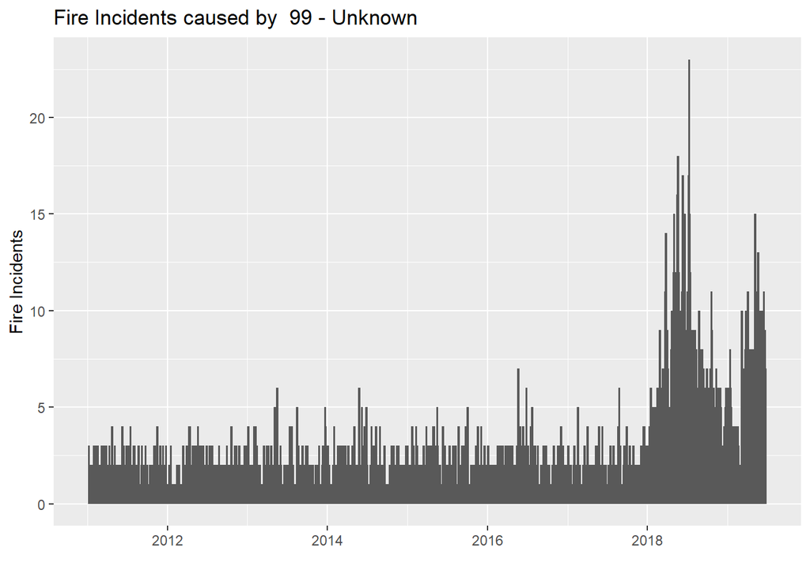

```r
plotCause <- function(cause){
  dtS = dtRaw[dtRaw$Possible_Cause_abb==cause,]
  dtSN = dtS[,.N,by=date]
  pic = ggplot(dtSN,aes(x=date,y=N))+
    geom_bar(position="dodge", stat="identity", width=10.11)+
    labs(y="Fire Incidents",x="")+
    ggtitle(paste0("Fire Incidents caused by  ",cause))+
    xlim(as.Date("2011-01-01"),as.Date("2019-06-30"))
  return(pic)
}
plotCause("99 - Unknown")
```

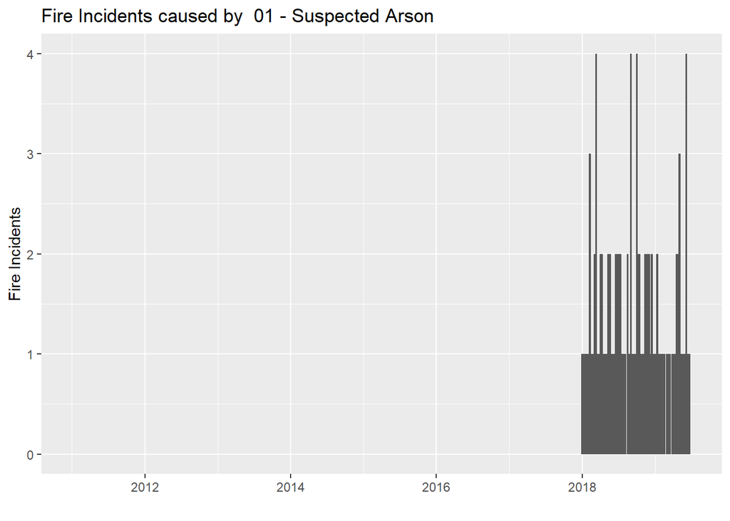

```r
plotCause("01 - Suspected Arson")
```

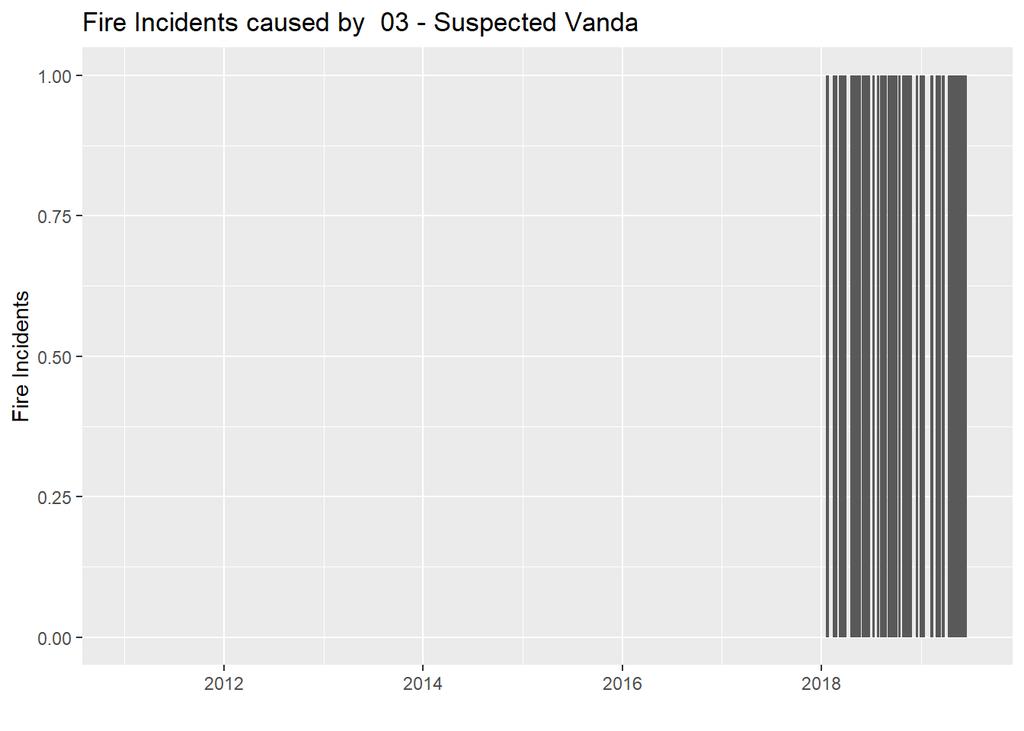

```r
plotCause("03 - Suspected Vanda")
```

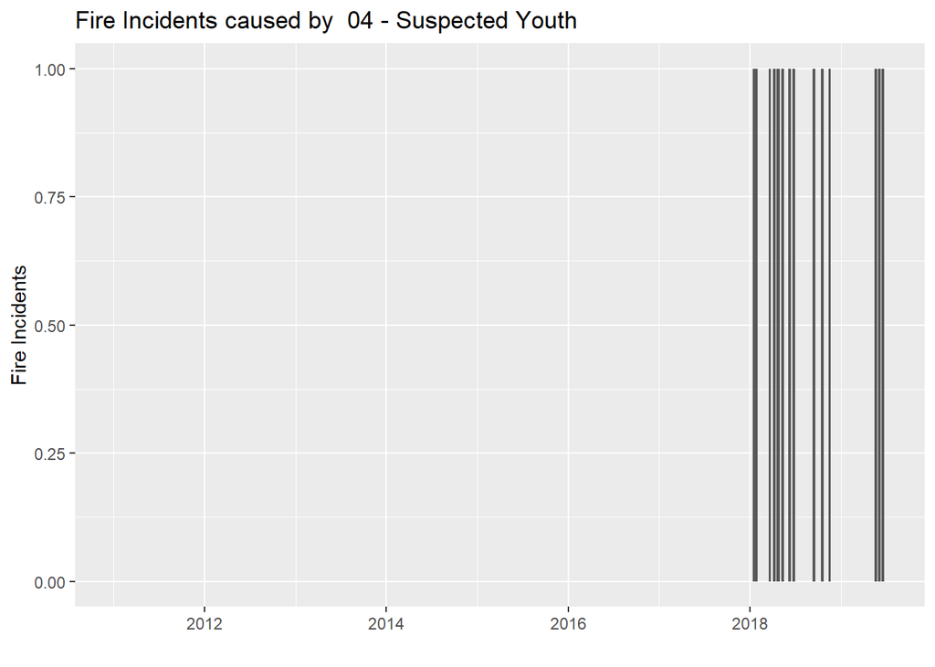

```r
plotCause("04 - Suspected Youth")
```

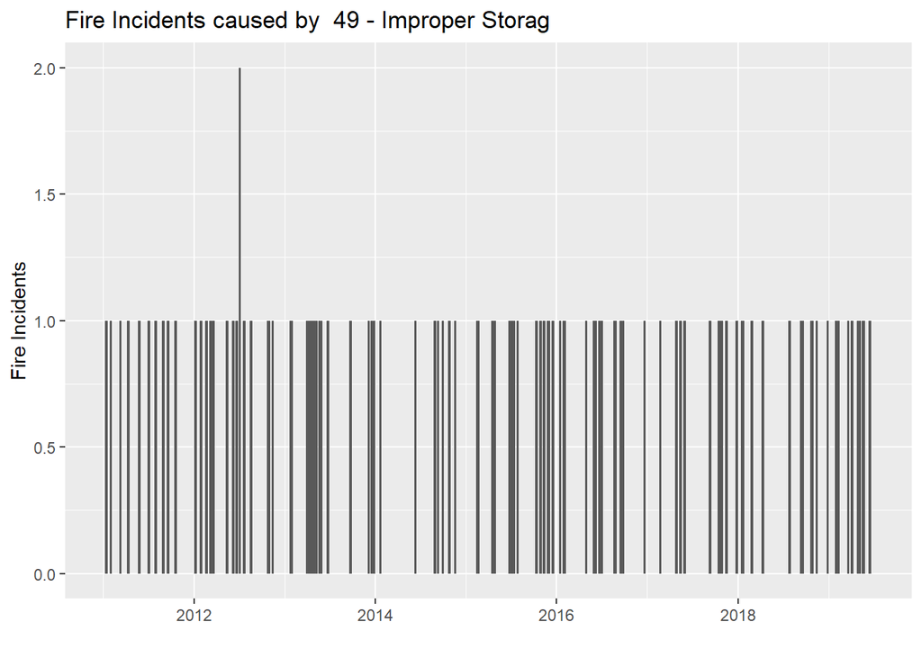

```r
plotCause("49 - Improper Storag")
```

# Weaknesses and next steps

Unfortunately, mainly rise of cause come from “99 - Unknown”. Unknown is unknown and we cannot forestall fire incidents with cause of unknown. The source of dataset cannot tell us why fire incidents with cause of unknown rise acutely. But we can inference that it took such a long time to make clear the cause of fire incidents that cause of fire in recent time was not determined.  
In next step, I will fit classification model by history data to predict cause of fire incidents and faster.

# References

- David F. Bauer, 1972, Constructing confidence sets using rank statistics. Journal of the American Statistical Association
- Myles Hollander and Douglas A. Wolfe ,1973, Nonparametric Statistical Methods. New York: John Wiley & Sons